# Machine learning algorithms

## Groups of algorithms

- grouping of algorithms by their learning style
- grouping of algorithms by their similarity in form or function

## Algorithms grouped by learning style

- Supervised Learning:
  - input data is called training data and has a known label/target variable
  - example problems are classification and regression
  - example algorithms include: Logistic Regression and the Back Propagation Neural Network
- Unsupervised Learning:
  - input data is not labeled and does not have a known result
  - a model is prepared by deducing structures present in the input data
  - example problems are clustering, dimensionality reduction and association rule learning
  - example algorithms include: the Apriori algorithm and K-Means
- Semi-Supervised Learning:
  - input data is a mixture of labeled and unlabelled examples
  - example problems are classification and regression
  - example algorithms are extensions to other flexible methods that make assumptions about how to model the unlabeled data

## Algorithms grouped by similarity

- a useful grouping method, but it is not perfect
- still algorithms that could just as easily fit into multiple categories like Learning Vector Quantization
- groups:
  - regression algorithms
  - instance-based algorithms
  - regularization algorithms
  - decision tree algorithms
  - Bayesian algorithms
  - clustering algorithms
  - association rule learning algorithms
  - artificial neural network algorithms
  - deep learning algorithms
  - dimensionality reduction algorithms
  - ensemble algorithms
  - other machine learning algorithms

## Regression algorithms

- modeling the relationship between variables that is iteratively refined using a measure of error in the predictions made by the model
- Ordinary Least Squares Regression (OLSR)
- Linear Regression
- Logistic Regression
- Stepwise Regression
- Multivariate Adaptive Regression Splines (MARS)
- Locally Estimated Scatterplot Smoothing (LOESS)

## Instance-based algorithms

- typically build up a database of example data and compare new data to the database using a similarity measure in order to find the best match and make a prediction
- k-Nearest Neighbor (kNN)
- Learning Vector Quantization (LVQ)
- Self-Organizing Map (SOM)
- Locally Weighted Learning (LWL)
- Support Vector Machines (SVM)

## Regularization algorithms

- an extension made to another method (typically regression methods) that penalizes models based on their complexity, favoring simpler models that are also better at generalizing
- Ridge Regression
- Least Absolute Shrinkage and Selection Operator (LASSO)
- Elastic Net
- Least-Angle Regression (LARS)

## Decision trees algorithms

- decisions fork in tree structures until a prediction decision is made for a given record
- often fast and accurate and a big favorite in machine learning
- Classification and Regression Tree (CART)
- Iterative Dichotomiser 3 (ID3)
- C4.5 and C5.0 (different versions of a powerful approach)
- Chi-squared Automatic Interaction Detection (CHAID)
- Decision Stump
- M5
- Conditional Decision Trees

## Bayesian algorithms

- explicitly apply Bayes’ Theorem for problems such as classification and regression
- Naive Bayes
- Gaussian Naive Bayes
- Multinomial Naive Bayes
- Averaged One-Dependence Estimators (AODE)
- Bayesian Belief Network (BBN)
- Bayesian Network (BN)

## Clustering algorithms

- typically organized by the modeling approaches such as centroid-based and hierarchical
- k-Means
- k-Medians
- Expectation Maximisation (EM)
- Hierarchical Clustering

## Association rule learning algorithms

- extract rules that best explain observed relationships between variables in data
- Apriori algorithm
- Frequent pattern growth algorithm (FP growth)
- Eclat algorithm

## Artificial neural network algorithms

- models that are inspired by the structure and/or function of biological neural networks
- Perceptron
- Multilayer Perceptrons (MLP)
- Back-Propagation
- Stochastic Gradient Descent
- Hopfield Network
- Radial Basis Function Network (RBFN)

## Deep learning algorithms

- a modern update to Artificial Neural Networks that exploit abundant cheap computation
- Convolutional Neural Network (CNN)
- Recurrent Neural Networks (RNNs)
- Long Short-Term Memory Networks (LSTMs)
- Stacked Auto-Encoders
- Deep Boltzmann Machine (DBM)
- Deep Belief Networks (DBN)

## Dimensionality reduction algorithms

- dmensionality reduction seek and exploit the inherent structure in the data, but in this case in an unsupervised manner or order to summarize or describe data using less information
- Principal Component Analysis (PCA)
- Principal Component Regression (PCR)
- Partial Least Squares Regression (PLSR)
- Sammon Mapping
- Multidimensional Scaling (MDS)
- Projection Pursuit
- Linear Discriminant Analysis (LDA)
- Mixture Discriminant Analysis (MDA)
- Quadratic Discriminant Analysis (QDA)
- Flexible Discriminant Analysis (FDA)

## Ensemble algorithms

- models composed of multiple weaker models that are independently trained and whose predictions are combined in some way to make the overall prediction
- Boosting
- Bootstrapped Aggregation (Bagging)
- AdaBoost
- Weighted Average (Blending)
- Stacked Generalization (Stacking)
- Gradient Boosting Machines (GBM)
- Gradient Boosted Regression Trees (GBRT)
- Random Forest

## Other machine learning algorithms

- Feature selection algorithms
- Algorithm accuracy evaluation
- Performance measures
- Optimization algorithms
- Computational intelligence (evolutionary algorithms, etc.)
- Computer Vision (CV)
- Natural Language Processing (NLP)
- Recommender Systems
- Reinforcement Learning
- Graphical Models
- And more…

## Focus on

- Linear regression
- Logistic regression
- Decision tree
- Random forest
- AdaBoost
- SVM
- FP-growth

## Linear regression - 1

- it is both a statistical algorithm and a machine learning algorithm
- an attractive model because the representation is so simple

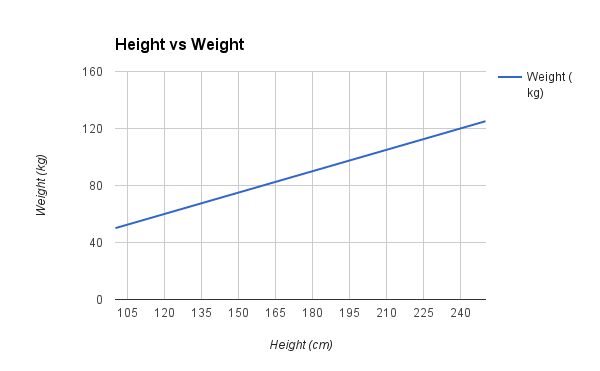

- preprocess data:
  - remove noise (removing outliers, especially in the output variable)
  - remove collinearity (danger of overfitting)
  - linear regression will make more reliable predictions if your input and output variables have a Gaussian distribution
  - rescale input

## Linear regression - 2

- METRICS:
  - Mean Absolute Error (MAE): measures the average of the absolute difference between each ground truth and the predictions
  - Root Mean Squared Error (RMSE): measures the square root of the average of the squared difference between the predictions and the ground truth; is more sensitive to outliers
  - MAE/RMSE must be compared with the dependent variable
  - R-Squared: o understand how well the independent variables “explain” the variance in your model, the R-Squared formula can be powerful
  - Adjusted R-squared: adds a penalty to the model for every additional variable

## Linear regression - 3

- PROS:
  - is simple to implement and easier to interpret the output coefficient
- CONS:
  - outliers can have huge effects on the regression
  - most of the problems aren’t linear
- IMPLEMENTATION:
  - R: lm
  - Python: [sklearn](https://scikit-learn.org/stable/modules/generated/sklearn.linear_model.LinearRegression.html)

## Logistic regression - 1

- another technique borrowed by machine learning from the field of statistics
- simple logistic regression (binary)
- Sigmoid Function

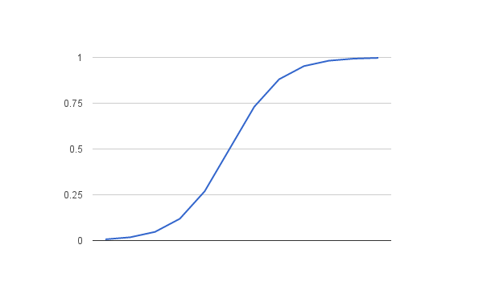

- modeling the probability that an input (X) belongs to the default class (Y=1)
- probability prediction must be transformed into a binary values (0 or 1)

## Logistic regression - 2

- multiple logistic regression
- basically we re-run binary classification multiple times, once for each class
- Softmax activation

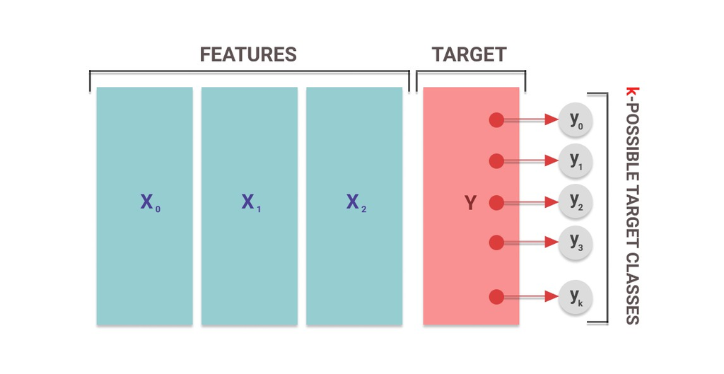

- METRICS:
  - likelihood ratio test
  - Pseudo R^2: McFadden’s R2 - the measure ranges from 0 to just under 1, with values closer to zero indicating that the model has no predictive power
  - variable importance
  - ROC curve: ranges from 0.50 to 1.00, and values above 0.80 indicate that the model does a good job

## Logistic regression - 3

- PROS:
  - one of the simplest machine learning algorithms
  - inference about the importance of each feature (trained weights)
  - fast
- CONS:
  - quickly leads to overfitting
  - sensitive to outliers
  - most of the problems aren’t linear
- IMPLEMENTATION:
  - R: [glm](https://www.rdocumentation.org/packages/stats/versions/3.6.2/topics/glm#:~:text=glm%20is%20used%20to%20fit,description%20of%20the%20error%20distribution.)
  - Python: [sklearn](https://scikit-learn.org/stable/modules/linear_model.html#logistic-regression)

## Decision trees - 1

- non-parametric supervised learning method

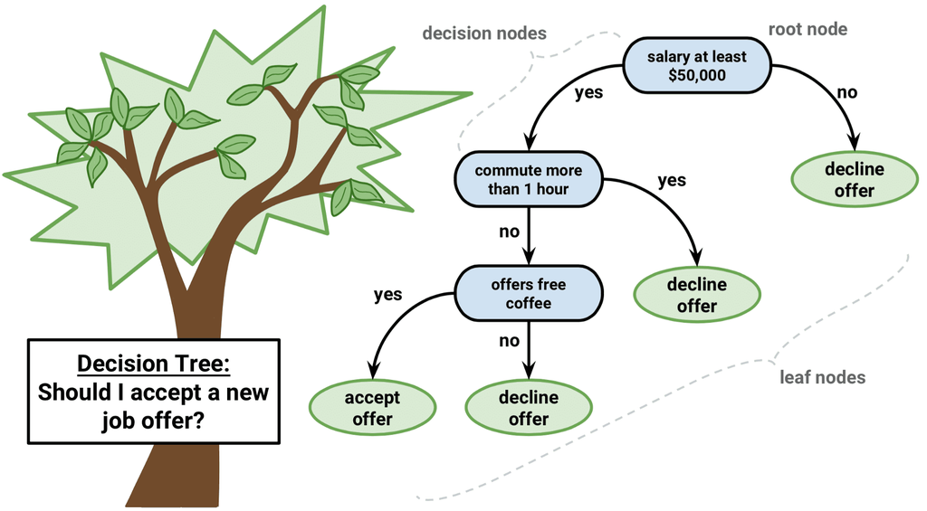

- top - bottom approach; selecting the best attribute (the best attribute is the one with the highest information gain)

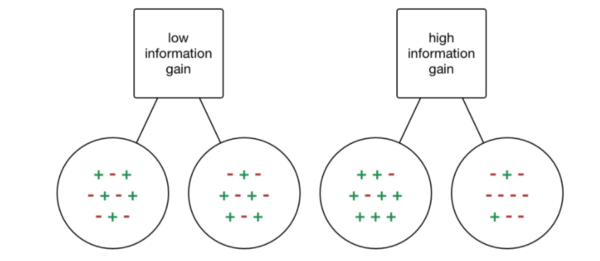

## Decision trees - 2

- METRICS:
  - confusion matrix:

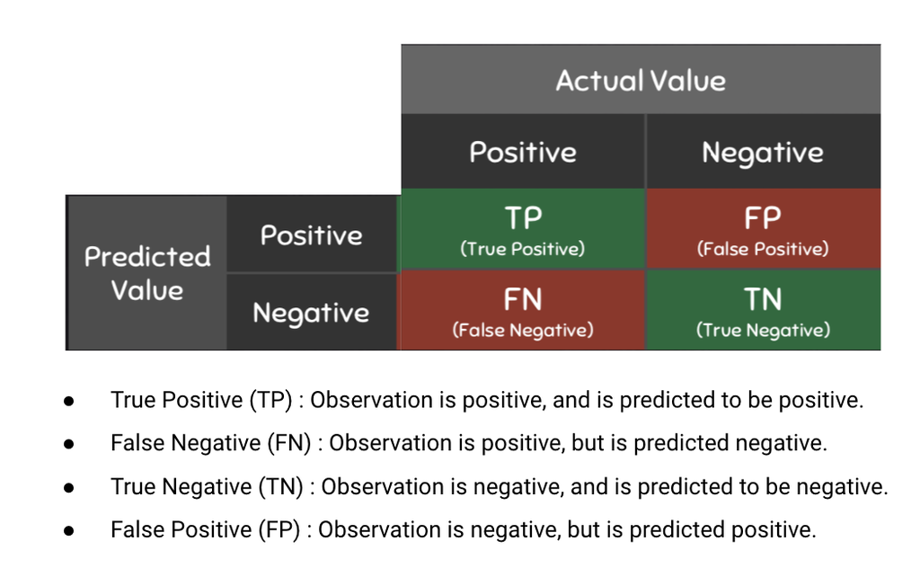

  - accuracy, precision, recall, F1 score:

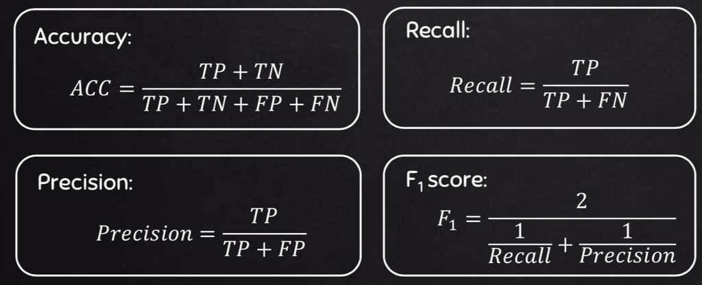

  - cost of FN > cost of FP –> recall; cost of FP > cost of FN –> precision

## Decision trees - 3

- PROS:
  - simple to understand and to interpret. Trees can be visualized
  - requires little data preparation
  - able to handle both numerical and categorical data
- CONS:
  - easily overfitting (solution pre-pruning and post-pruning)
  - unstable, meaning that a small change in the data can lead to a large change in the structure of the optimal decision tree
  - decision tree algorithm is inadequate for applying regression and predicting continuous values
  - often involves higher time to train the model
- IMPLEMENTATION:
  - R: [rpart](https://www.rdocumentation.org/packages/rpart/versions/4.1-15)
  - Python: [sklearn](https://scikit-learn.org/stable/modules/tree.html)

## Random forest - 1

- consists of a large number of individual decision trees that operate as an ensemble

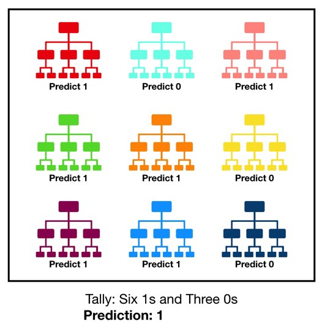

- predictions (and therefore the errors) made by the individual trees need to have low correlations with each other
- bagging: allowing each individual tree to randomly sample from the dataset with replacement, resulting in different trees
- splitting a node: each tree in a random forest can pick only from a random subset of features

## Random forest - 2

- METRICS: the same as for DT
- PROS:
  - great with High dimensionality
  - quick prediction/training speed
  - robust to outliers and non-linear data
  - hHandles unbalanced data
- CONS:
  - model interpretability: Random forest models are not all that interpretable; they are like black boxes
  - for very large data sets, the size of the trees can take up a lot of memory
  - tends to overfit, so you should tune the hyperparameters
- IMPLEMENTATION:
  - R: [randomForest](https://cran.r-project.org/web/packages/randomForest/index.html)
  - Python: [sklearn](https://scikit-learn.org/stable/modules/generated/sklearn.ensemble.RandomForestClassifier.html#sklearn.ensemble.RandomForestClassifier)

## Adabost - 1

- an ensemble algorithm
- AdaBoost is best used to boost the performance of decision trees on binary classification problems

[figure not shown]

## Adabost - 2 {.smaller}

- METRICS: the same as for DT
- PROS:
  - very good use of weak classifiers for cascading
  - different classification algorithms can be used as weak classifiers
  - AdaBoost has a high degree of precision
- CONS:
  - data imbalance leads to a decrease in classification accuracy
  - training is time consuming
- IMPLEMENTATION:
  - R: adaboost
  - Python: [sklearn](https://scikit-learn.org/stable/modules/generated/sklearn.ensemble.AdaBoostClassifier.html)

## SVM - 1

- machine learning algorithms which are used both for classification and regression; but generally, they are used in classification problems
- the decision boundary that maximizes the distance (maximum margin classifier) from the nearest data points of all the classes

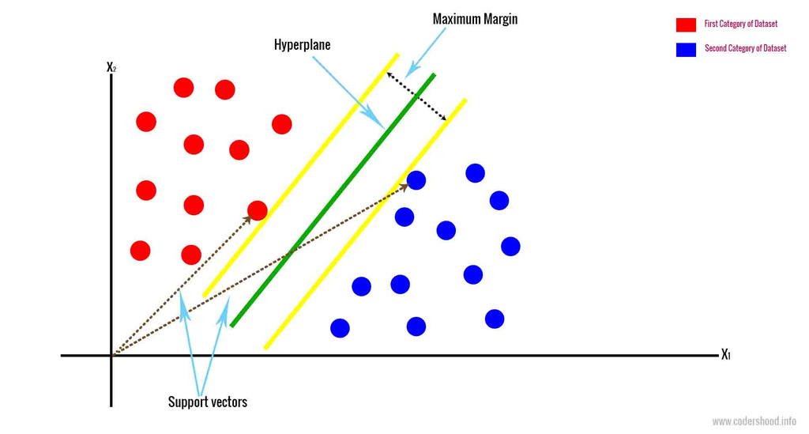

- the decision boundary doesn’t have to be a line; it’s also referred to as a hyperplane because you can find the decision boundary with any number of features, not just two
- SVM algorithms aren’t scale invariant

## SVM - 2

- METRICS: the same as for DT
- PROS:
  - Effective on datasets with multiple features, like financial or medical data
  - memory efficient
- CONS:
  - SVMs don’t directly provide probability estimates
  - works best on small sample sets because of its high training time
- IMPLEMENTATION:
  - R: svm
  - Python: [sklearn](https://scikit-learn.org/stable/modules/svm.html)

## FP-growth - 1

- market basket analysis
- represents the database in the form of a tree called a frequent pattern tree or FP tree
- the database is fragmented using one frequent item
- the itemsets of these fragmented patterns are analyzed
- PROS:
  - algorithm needs to scan the database only twice when compared to Apriori
  - efficient and scalable for mining both long and short frequent patterns
- CONS:
  - FP Tree is more cumbersome and difficult to build than Apriori
  - It may be “expensive”

## FP-growth - 2

- METRICS:
  - Support: indication of how frequently the itemset appears in the dataset
  - Confidence: indication of how often the rule has been found to be true
  - Lift: a useful measure to determine the strength of the association between the items in a rule
  - Conviction: the frequency that the rule makes an incorrect prediction if X and Y were independent divided by the observed frequency of incorrect predictions
- IMPLEMENTATION:
  - R: rCBA
  - Python: [pyfpgrowth](https://pypi.org/project/pyfpgrowth/)

## Neural network: feed-forward - 1

- biologically inspired classification algorithm
- every unit in a layer is connected with all the units in the previous layer
- each connection may have a different strength or weight
- there is no feedback between layers

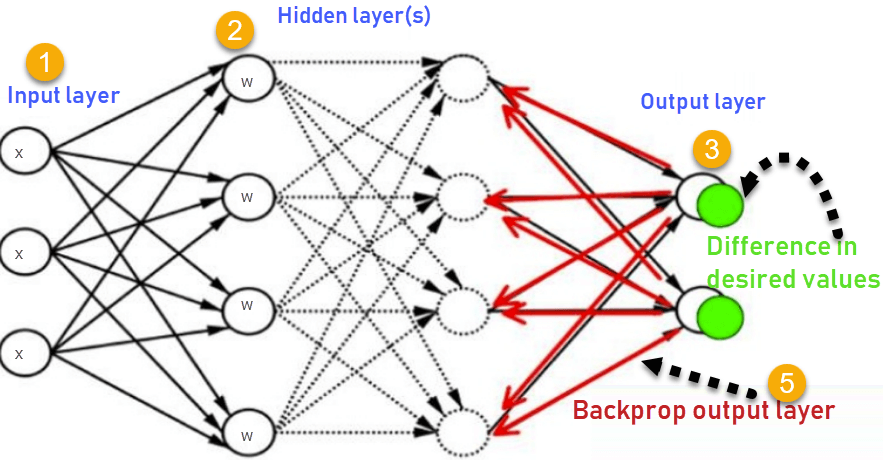

- besides the input pattern, the neural net also needs to know to what category the pattern belongs
- the units in the output layer all belong to a different category

## Neural network: feed-forward - 2

- the unit with the correct category would have had the largest output value; the output values of the other output units would have been very small
- on the basis of this comparison all the connection weights are modified a little bit
- greater modification, faster learning, but usually overshooting
- the output values are compared with the correct answer to compute the value of some predefined error-function
- METRICS: the same as for DT (classification)
- PROS:
  - fast, simple and easy to program
  - it does not require prior knowledge about the network
  - it is a standard method that generally works well

## Neural network: feed-forward - 3

- CONS:
  - can be quite sensitive to noisy data
- IMPLEMENTATION:
  - R: neuralnet
  - Python: pytorch